# Week 5B Getting Data Part 1: Working with APIs

Oct 6, 2021

## Week #5 Agenda

**Last time**:

- Introduction to APIs
- Pulling census data and shape files using Python

**Today:**

- API Example: Lead poisoning in Philadelphia
- Using the Twitter API
  - Plotting geocoded tweets
  - Word frequencies
  - Sentiment analysis

```python
import geopandas as gpd
import pandas as pd
import numpy as np
from shapely.geometry import Point

from matplotlib import pyplot as plt
import seaborn as sns

import hvplot.pandas
import holoviews as hv
```

```python
import esri2gpd
import carto2gpd
import cenpy
```

```python
pd.options.display.max_columns = 999
```

## Last time: Querying the census with cenpy

First, let's initialize a connection to the 2019 5-year ACS dataset

```python
acs = cenpy.remote.APIConnection("ACSDT5Y2019")
```

```python
# Set the map service for pulling geometries
acs.set_mapservice("tigerWMS_ACS2019")
```

```
Connection to American Community Survey: 5-Year Estimates: Detailed Tables 5-Year(ID: https://api.census.gov/data/id/ACSDT5Y2019)
With MapServer: Census ACS 2019 WMS
```

## Exercise: lead poisoning in Philadelphia

Let's use demographic census data in Philadelphia by **census tract** and compare to a dataset of childhood lead poisoning.

### Step 1. Download the demographic data for Philadelphia

- We are going to be examining the percent of the population that identifies as black in each census tract, so we will need:
  - Total population: 'B03002_001E'
  - Non-Hispanic, Black population: 'B03002_004E'
- You'll want to use the state --> county --> tract hierarchy , using the `*` operator to get all tracts in Philadelphia county
- Remember PA has a FIPS code of "42" and Philadelphia County is "101"

```python
philly_demo_tract = acs.query(
    cols=["NAME", "B03002_001E", "B03002_004E"],
    geo_unit="tract:*",
    geo_filter={
                "state" : "42",
                "county" : "101"
               },
)
```

```python
philly_demo_tract.head()
```

|  | NAME | B03002_001E | B03002_004E | state | county | tract |
| --- | --- | --- | --- | --- | --- | --- |
| 0 | Census Tract 260, Philadelphia County, Pennsyl... | 3055 | 2717 | 42 | 101 | 026000 |
| 1 | Census Tract 263.02, Philadelphia County, Penn... | 4927 | 4704 | 42 | 101 | 026302 |
| 2 | Census Tract 264, Philadelphia County, Pennsyl... | 5660 | 5576 | 42 | 101 | 026400 |
| 3 | Census Tract 101, Philadelphia County, Pennsyl... | 6925 | 6671 | 42 | 101 | 010100 |
| 4 | Census Tract 107, Philadelphia County, Pennsyl... | 3612 | 3301 | 42 | 101 | 010700 |

```python
philly_demo_tract.dtypes # "object" means string!
```

```
NAME           object
B03002_001E    object
B03002_004E    object
state          object
county         object
tract          object
dtype: object
```

### Step 2. Download and merge in the census tract geometries

```python
# Census tracts are the 9th layer (index 8 starting from 0)
acs.mapservice.layers[8]
```

```
(ESRILayer) Census Tracts
```

### Option 1: Use esri2gpd to load the data

```python
# The base url for the map service API endpoint
acs.mapservice._baseurl
```

```
'http://tigerweb.geo.census.gov/arcgis/rest/services/TIGERweb/tigerWMS_ACS2019/MapServer'
```

```python
## We're just querying a GeoService — let's use esri2gpd

# Only Philadelphia
where_clause = "STATE = 42 AND COUNTY = 101"

# Create the API url with the layer ID add the end
url = f"{acs.mapservice._baseurl}/8"

# Query
philly_census_tracts = esri2gpd.get(url, where=where_clause)
```

### Option 2: Query the map service in cenpy

```python
# Query for census tracts using cenpy API
# philly_census_tracts = acs.mapservice.layers[8].query(where=where_clause)
```

```python
philly_census_tracts.head(n=1)
```

|  | geometry | MTFCC | OID | GEOID | STATE | COUNTY | TRACT | BASENAME | NAME | LSADC | FUNCSTAT | AREALAND | AREAWATER | CENTLAT | CENTLON | INTPTLAT | INTPTLON | OBJECTID |
| --- | --- | --- | --- | --- | --- | --- | --- | --- | --- | --- | --- | --- | --- | --- | --- | --- | --- | --- |
| 0 | POLYGON ((-75.05110 40.02641, -75.05065 40.025... | G5020 | 20759510236568 | 42101032500 | 42 | 101 | 032500 | 325 | Census Tract 325 | CT | S | 839319 | 0 | +40.0263918 | -075.0452561 | +40.0263918 | -075.0452561 | 1554 |

```python
philly_census_tracts.dtypes
```

```
geometry     geometry
MTFCC          object
OID            object
GEOID          object
STATE          object
COUNTY         object
TRACT          object
BASENAME       object
NAME           object
LSADC          object
FUNCSTAT       object
AREALAND        int64
AREAWATER       int64
CENTLAT        object
CENTLON        object
INTPTLAT       object
INTPTLON       object
OBJECTID        int64
dtype: object
```

```python
philly_demo_tract.head(n=1)
```

|  | NAME | B03002_001E | B03002_004E | state | county | tract |
| --- | --- | --- | --- | --- | --- | --- |
| 0 | Census Tract 260, Philadelphia County, Pennsyl... | 3055 | 2717 | 42 | 101 | 026000 |

```python
# Merge them together
# IMPORTANT: Make sure your merge keys are the same dtypes (e.g., all strings or all ints)
philly_demo_tract = philly_census_tracts.merge(
    philly_demo_tract,
    left_on=["STATE", "COUNTY", "TRACT"],
    right_on=["state", "county", "tract"],
)
```

### Step 3. Calculate the black percentage

Add a new column to your data called `percent_black`.

**Important:** Make sure you convert the data to floats!

```python
for col in ['B03002_001E', 'B03002_004E']:
    philly_demo_tract[col] = philly_demo_tract[col].astype(float)
```

```python
philly_demo_tract["percent_black"] = (
    100 * philly_demo_tract["B03002_004E"] / philly_demo_tract["B03002_001E"]
)
```

### Step 4. Query CARTO to get the childhood lead levels by census tract

- The API documentation for this data is here: https://cityofphiladelphia.github.io/carto-api-explorer/#child_blood_lead_levels_by_ct
- You can use the `carto2gpd` package
  - You'll need the API endpoint for CARTO and the name of the table

```python
# Documentation includes an example for help!
# carto2gpd.get?
```

```python
table_name = 'child_blood_lead_levels_by_ct'
lead_levels = carto2gpd.get("https://phl.carto.com/api/v2/sql", table_name)
```

```python
lead_levels.head()
```

|  | geometry | cartodb_id | census_tract | data_redacted | num_bll_5plus | num_screen | perc_5plus |
| --- | --- | --- | --- | --- | --- | --- | --- |
| 0 | POLYGON ((-75.14147 39.95171, -75.14150 39.951... | 1 | 42101000100 | False | 0.0 | 100.0 | 0.0 |
| 1 | POLYGON ((-75.16238 39.95766, -75.16236 39.957... | 2 | 42101000200 | True | NaN | 109.0 | NaN |
| 2 | POLYGON ((-75.17821 39.95981, -75.17743 39.959... | 3 | 42101000300 | True | NaN | 110.0 | NaN |
| 3 | POLYGON ((-75.17299 39.95464, -75.17301 39.954... | 4 | 42101000401 | True | NaN | 61.0 | NaN |
| 4 | POLYGON ((-75.16333 39.95334, -75.16340 39.953... | 5 | 42101000402 | False | 0.0 | 41.0 | 0.0 |

### Step 5. Remove census tracts with missing lead measurements

See the `.dropna()` function and the `subset=` keyword.

```python
lead_levels = lead_levels.dropna(subset=['perc_5plus'])
```

### Step 6. Merge the demographic and lead level data frames

- From the lead data, we only need the 'census_tract' and 'perc_5plus'. Before merging, trim your data to only these columns.
- You can perform the merge by comparing the `census_tract` and `GEOID` fields
- Remember: when merging, the left data frame should be the GeoDataFrame — use `GeoDataFrame.merge(...)`

```python
# Trim the lead levels data
lead_levels_trimmed = lead_levels[['census_tract', 'perc_5plus']]

# Merge into the demographic data
# Use "GEOID" — that is the unique identifier here
merged = philly_demo_tract.merge(lead_levels_trimmed,
                                 how='left',
                                 left_on='GEOID',
                                 right_on='census_tract')
```

```python
merged.head()
```

|  | geometry | MTFCC | OID | GEOID | STATE | COUNTY | TRACT | BASENAME | NAME_x | LSADC | FUNCSTAT | AREALAND | AREAWATER | CENTLAT | CENTLON | INTPTLAT | INTPTLON | OBJECTID | NAME_y | B03002_001E | B03002_004E | state | county | tract | percent_black | census_tract | perc_5plus |
| --- | --- | --- | --- | --- | --- | --- | --- | --- | --- | --- | --- | --- | --- | --- | --- | --- | --- | --- | --- | --- | --- | --- | --- | --- | --- | --- | --- |
| 0 | POLYGON ((-75.05110 40.02641, -75.05065 40.025... | G5020 | 20759510236568 | 42101032500 | 42 | 101 | 032500 | 325 | Census Tract 325 | CT | S | 839319 | 0 | +40.0263918 | -075.0452561 | +40.0263918 | -075.0452561 | 1554 | Census Tract 325, Philadelphia County, Pennsyl... | 6143.0 | 1200.0 | 42 | 101 | 032500 | 19.534429 | 42101032500 | 2.9 |
| 1 | POLYGON ((-75.16012 39.94340, -75.16020 39.943... | G5020 | 207593717001443 | 42101001102 | 42 | 101 | 001102 | 11.02 | Census Tract 11.02 | CT | S | 204063 | 0 | +39.9442654 | -075.1566960 | +39.9442654 | -075.1566960 | 1910 | Census Tract 11.02, Philadelphia County, Penns... | 2687.0 | 257.0 | 42 | 101 | 001102 | 9.564570 | NaN | NaN |
| 2 | POLYGON ((-75.17776 39.94897, -75.17784 39.948... | G5020 | 207593717001453 | 42101000803 | 42 | 101 | 000803 | 8.03 | Census Tract 8.03 | CT | S | 152822 | 0 | +39.9493748 | -075.1742489 | +39.9493748 | -075.1742489 | 1911 | Census Tract 8.03, Philadelphia County, Pennsy... | 2774.0 | 81.0 | 42 | 101 | 000803 | 2.919971 | 42101000803 | 0.0 |
| 3 | POLYGON ((-75.26108 39.87660, -75.26125 39.876... | G5020 | 207593717001459 | 42101980900 | 42 | 101 | 980900 | 9809 | Census Tract 9809 | CT | S | 17332840 | 3354833 | +39.9015541 | -075.2140251 | +39.9051802 | -075.2174146 | 1912 | Census Tract 9809, Philadelphia County, Pennsy... | 0.0 | 0.0 | 42 | 101 | 980900 | NaN | NaN | NaN |
| 4 | POLYGON ((-75.17226 39.99671, -75.17235 39.996... | G5020 | 207593717001480 | 42101017201 | 42 | 101 | 017201 | 172.01 | Census Tract 172.01 | CT | S | 262958 | 0 | +39.9993972 | -075.1686145 | +39.9993972 | -075.1686145 | 1957 | Census Tract 172.01, Philadelphia County, Penn... | 2835.0 | 2146.0 | 42 | 101 | 017201 | 75.696649 | 42101017201 | 12.8 |

### Step 7. Trim to the columns we need

We only need the 'geometry', 'percent_black', and 'perc_5plus', and 'NAME' columns

```python
merged = merged[['NAME_x', 'geometry', 'percent_black', 'perc_5plus']]
```

### Step 8. Plot the results

Make two plots:

1. A two panel, side-by-side chart showing a choropleth of the lead levels and the percent black
2. A scatter plot showing the percentage

You can make these using hvplot or geopandas/matplotlib — whichever you prefer!

```python
# Lead levels plot
img1 = merged.hvplot(geo=True,
                     crs=3857,
                     c='perc_5plus',
                     width=500,
                     height=400,
                     cmap='viridis',
                     title='Lead Levels')

# Percent black
img2 = merged.hvplot(geo=True,
                     crs=3857,
                     c='percent_black',
                     width=500,
                     height=400,
                     cmap='viridis',
                     title='% Black')

img1 + img2
```

[interactive chart not shown]

```python
cols = ['perc_5plus', 'percent_black']
merged[cols].hvplot.scatter(x=cols[0], y=cols[1])
```

[interactive chart not shown]

### Challenge: Step 9. Use seaborn to plot a 2d density map

In the previous plots, it's still hard to see the relationship. Use the `kdeplot()` function in `seaborn` to better visualize the relationship.

You will need to remove any NaN entries first.

You should see two peaks in the distribution clearly now!

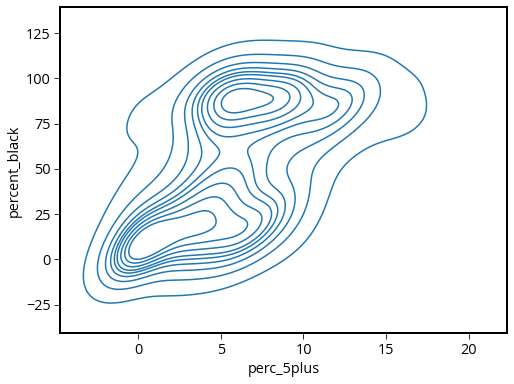

```python
fig, ax = plt.subplots(figsize=(8,6))

X = merged.dropna()
sns.kdeplot(x=X['perc_5plus'], y=X['percent_black'], ax=ax);
```

## API Example #2: the Twitter API

Twitter provides a rich source of information, but the challenge is how to extract the information from **semi-structured** data.

## Semi-structured data

Data that contains some elements that cannot be easily consumed by computers

**Examples:** human-readable text, audio, images, etc

## Key challenges

- **Text mining**: analyzing blocks of text to extract the relevant pieces of information
- **Natural language processing (NLP)**: programming computers to process and analyze human languages
- **Sentiment analysis**: analyzing blocks of text to derive the attitude or emotional state of the person

## First: Getting an API key

### Step 1: Make a Twitter account

### Step 2: Apply for Developer access

See: https://developer.twitter.com/apps

You will need to apply for a Developer Account, answering a few questions, and then confirm your email address.

Once you submit you'll application, you'll need to wait for approval...usually this happens immediately, but there can sometimes be a short delay

### Sample answer

**Needs to be at least 100 characters**

### Step 3: Create a new app

https://developer.twitter.com/en/apps/create

### Step 4: Create your API keys

In the "Keys and Tokens" section, generate new access tokens.

You will need the Consumer API keys and access tokens to use the Twitter API.

## We'll be using `tweepy` to search recent tweets

The standard, free API let's you search tweets from the last 7 days

For more information, see the [Twitter Developer docs](https://developer.twitter.com/en/docs/basics/getting-started)

## Tweepy: a Python interface to Twitter

https://tweepy.readthedocs.io

```python
import tweepy as tw
```

## Define your API keys

```python
# INPUT YOUR API AND ACCESS KEYS HERE
api_key = ""
api_key_secret = ""
access_token = ""
access_token_secret = ""
```

## Initialize an API object

We need to:

- step up authentication
- intialize a `tweepy.API` object

```python
auth = tw.OAuthHandler(api_key, api_key_secret)
auth.set_access_token(access_token, access_token_secret)


api = tw.API(auth, wait_on_rate_limit=True)
```

## Rate Limits

See the [Rate Limits](https://developer.twitter.com/en/docs/basics/rate-limiting.html) documentation for more details.

## What does `wait_on_rate_limit` do?

If you run into a rate limit while pulling tweets, this will tell `tweepy` to wait 15 minutes until it can continue.

Unfortunately, you need to sign up (and pay) for the [premium API](https://developer.twitter.com/en/premium-apis.html) to avoid these rate limits.

## How to find out how many requests you've made?

```python
data = api.rate_limit_status()
```

```python
data
```

[output not shown]

[output cut: 592 more lines]

```
   '/oauth/revoke_html': {'limit': 15, 'remaining': 15, 'reset': 1633655934}},
  'search': {'/search/tweets': {'limit': 180,
    'remaining': 180,
    'reset': 1633655934}},
  'trends': {'/trends/closest': {'limit': 75,
    'remaining': 75,
    'reset': 1633655934},
   '/trends/available': {'limit': 75, 'remaining': 75, 'reset': 1633655934},
   '/trends/place': {'limit': 75, 'remaining': 75, 'reset': 1633655934}},
  'live_pipeline': {'/live_pipeline/events': {'limit': 180,
    'remaining': 180,
    'reset': 1633655934}},
  'graphql': {'/graphql': {'limit': 15,
    'remaining': 15,
    'reset': 1633655934}}}}
```

```python
data['resources']['search']
```

```
{'/search/tweets': {'limit': 180, 'remaining': 180, 'reset': 1633655934}}
```

## Tip: converting a time stamp to a date

```python
import datetime
datetime.datetime.fromtimestamp(1633566967)
```

```
datetime.datetime(2021, 10, 6, 20, 36, 7)
```

## Several different APIs available

Including user tweets, mentions, searching keywords, favoriting, direct messages, and more...

See the [Tweepy API documentation](https://tweepy.readthedocs.io/en/3.7.0/api.html)

## You can also stream tweets

You can set up a **listener** to listen for new tweets and download them in real time (subject to rate limits).

We won't focus on this, but there is a nice [tutorial](https://tweepy.readthedocs.io/en/3.7.0/streaming_how_to.html) on the Tweepy documentation.

## You can also tweet (if you want!)

You can post tweets using the `update_status()` function. For example:

```
tweet = 'Hello World! @PennMusa'
api.update_status(tweet)
```

## We'll focus on the search API

We'll use a `tweepy.Cursor` object to query the API.

```python
# collect tweets related to the eagles
search_words = "#eagles"
```

```python
# initialize the cursor
cursor = tw.Cursor(api.search,
                   q=search_words,
                   lang="en",
                   tweet_mode='extended')
cursor
```

```
<tweepy.cursor.Cursor at 0x7fb92bedafa0>
```

## Next, specify how many tweets we want

Use the `Cursor.items()` function:

```python
# select 5 tweets
tweets = cursor.items(5)
tweets
```

```
<tweepy.cursor.ItemIterator at 0x7fb92bece4c0>
```

## Python iterators

As the name suggests, **iterators** need to be iterated over to return objects. In our case, we can use a for loop to iterate through the tweets that we pulled from the API.

```python
# Iterate on tweets
for tweet in tweets:
    print(tweet.full_text)
```

```
RT @Jeff_McLane: Jason Kelce, who didn’t practice Wed because of “foot/rest,” just went indoors. Hasn’t come out in a bit. Will update. #Ea…
RT @Jeff_McLane: No Lane Johnson again at #Eagles practice. Still dealing with a personal issue. Looking more and more unlikely he’ll be in…
RT @Jeff_McLane: #Eagles beat writers make their predictions for the Panthers game in Week 5: Will the losing streak end?

From @EJSmith94,…
RT @Jeff_McLane: Narrative Fletcher Cox sees only doubles is false. Number based upon film review is exactly half.

More obvious answer for…
RT @Jeff_McLane: #Eagles’ Lane Johnson not back with team; Jordan Mailata making progress. @EJSmith94: https://t.co/zIwrUL8wXO via @phillyi…
```

## The concept of "paging"

**Unfortunately, there is no way to search for tweets between specific dates.**

The API pulls tweets from the most recent page of the search result, and then grabs tweets from the previous page, and so on, to return the requested number of tweets.

## Customizing our search query

The [API documentation](https://developer.twitter.com/en/docs/tweets/rules-and-filtering/overview/standard-operators) has examples of different query string use cases

## Examples

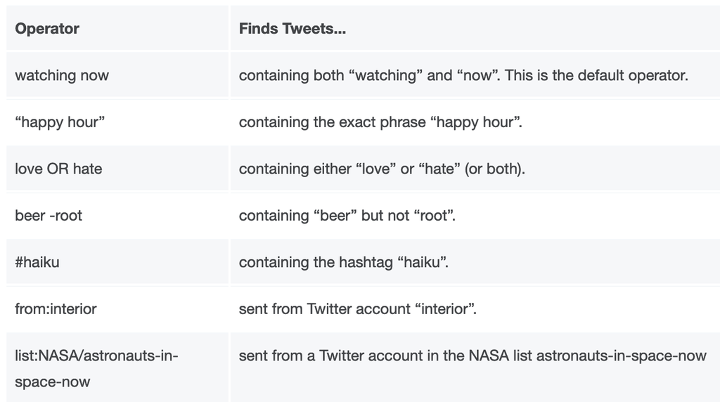

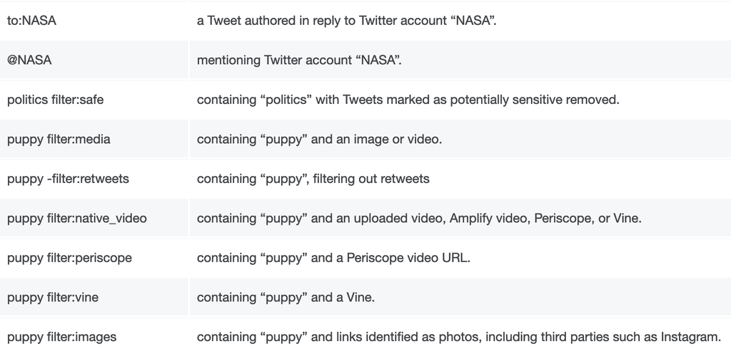

## Let's remove retweets

```python
new_search = search_words + " -filter:retweets"
```

Get a new tweets using our new search query:

```python
cursor = tw.Cursor(api.search,
                   q=new_search,
                   lang="en",
                   tweet_mode='extended')
tweets = cursor.items(5)
```

## Did it work?

```python
for tweet in tweets:
    print(tweet.full_text)
```

```
**Ending Soon**
#EAGLES 7" #VINYL #SINGLE #1970s EX/EX https://t.co/vcSOVppSBl via @eBay_UK #records #OneOfTheseNights #ebay
November 20, 1960 - Chuck Bednarik (60) of the Eagles walks off the field after game against the Giants at Yankee Stadium.
#Philadelphia #Eagles #NFL #1960s #FlyEaglesFly https://t.co/wFfUjQS8W3
Every time I watch the #Seahawks I say THANK GOD the #Eagles passed on this turd DK Metcalf for… &lt;CHECKS NOTES&gt;… JJ Arcega-Whiteside! 🧐😞
New Kultural Sport Episode!! NFL 2021 WEEK 4 RECAP/ WEEK 5 PREDICTIONS. Click link below and hit that subscribe button greatly appreciate it! #ColtsNation #colts #Eagles #NFL #sports #

https://t.co/t1MhprSIcg https://t.co/HQugdiCsaQ
NEW: #Eagles Thurs notebook:
-OL speculation. "If you knew what the lineup would be, it would be let’s attack this...right now we’re just trying to attack scheme the best we can”
-DeVonta Smith's training and "stepping stone"
-Christian McCaffery
And more:
https://t.co/rTLSBf7Rm3
```

## How to save the tweets?

Create a list of the tweets using Python's inline syntax

```python
# select the next 10 tweets
tweets = [t for t in cursor.items(10)]

print(len(tweets))
```

```
10
```

## A wealth of information is available

Beyond the text of the tweet, things like favorite and retweet counts are available. You can also extract info on the user behind the tweet.

```python
first_tweet = tweets[0]
```

```python
first_tweet.full_text
```

```
'Ryan Paganetti, Former #Eagles Assistant Coach &amp; Gameday management specialist Breaks Down 2021 Eagles... https://t.co/BnLOGa1sKe via @YouTube'
```

```python
first_tweet.favorite_count
```

```
1
```

```python
first_tweet.created_at
```

```
datetime.datetime(2021, 10, 7, 23, 44, 51)
```

```python
first_tweet.retweet_count
```

```
1
```

```python
first_tweet.user.description
```

```
'#NFL 🏈, #Eagles insider 🎙️📝for @sinow, @thephillyvoice, @JAKIBMedia, @birds365show, @6ABC postgame, @ExtendthePlay & #Football247 on @1490SportsBet. DM Me'
```

```python
first_tweet.user.followers_count
```

```
7185
```

## Let's extract screen names and locations

A fraction of tweets have locations associated with user profiles, giving (very rough) location data.

```python
users_locs = [[tweet.user.screen_name, tweet.user.location] for tweet in tweets]
users_locs
```

```
[['JFMcMullen', 'Philadelphia'],
 ['champton0927', ''],
 ['FlamingOldies1', 'Worcester, Massachusetts'],
 ['ThomasFox_4th', 'Vermont, USA'],
 ['designguyca', 'South Coast of Canada'],
 ['ByADiBona', 'Brooklyn, NY'],
 ['nflrums', 'Georgia '],
 ['kracze', 'Bucks County, PA'],
 ['RonBohning', 'Fayetteville, AR'],
 ['DSM_Media', 'Philadelphia, PA']]
```

**Note**: only about 1% of tweets have a latitude/longitude.

Difficult to extract geographic trends without pulling a large number of tweets, requiring a premium API.

## Use case #1: calculating word frequencies

An example of **text mining**

## Load the most recent 1,000 tweets

Save the text of 1,000 tweets after querying our cursor object.

```python
cursor = tw.Cursor(api.search,
                   q="#eagles -filter:retweets",
                   lang="en",
                   tweet_mode='extended')
tweets = [tweet for tweet in cursor.items(1000)]
```

```python
# get the text of the tweets
tweets_text = [tweet.full_text for tweet in tweets]
```

```python
# the first five tweets
tweets_text[:5]
```

```
['**Ending Soon**\n#EAGLES 7" #VINYL #SINGLE #1970s EX/EX https://t.co/vcSOVppSBl via @eBay_UK #records #OneOfTheseNights #ebay',
 'November 20, 1960 - Chuck Bednarik (60) of the Eagles walks off the field after game against the Giants at Yankee Stadium.\n#Philadelphia #Eagles #NFL #1960s #FlyEaglesFly https://t.co/wFfUjQS8W3',
 'Every time I watch the #Seahawks I say THANK GOD the #Eagles passed on this turd DK Metcalf for… &lt;CHECKS NOTES&gt;… JJ Arcega-Whiteside! 🧐😞',
 'New Kultural Sport Episode!! NFL 2021 WEEK 4 RECAP/ WEEK 5 PREDICTIONS. Click link below and hit that subscribe button greatly appreciate it! #ColtsNation #colts #Eagles #NFL #sports #\n\nhttps://t.co/t1MhprSIcg https://t.co/HQugdiCsaQ',
 'NEW: #Eagles Thurs notebook:\n-OL speculation. "If you knew what the lineup would be, it would be let’s attack this...right now we’re just trying to attack scheme the best we can”\n-DeVonta Smith\'s training and "stepping stone"\n-Christian McCaffery\nAnd more:\nhttps://t.co/rTLSBf7Rm3']
```

## Text mining and dealing with messy data

1. Remove URLs $\rightarrow$ regular expressions
2. Remove **stop words**
3. Remove the search terms

## Step 1: removing URLs

### Regular expressions

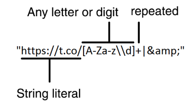

This will identify "t.co" in URLs, e.g. https://t.co/Sp1Qtf5Fnl

Don't worry about mastering regular expression syntax...

StackOverflow is your friend

```python
def remove_url(txt):
    """
    Replace URLs found in a text string with nothing
    (i.e. it will remove the URL from the string).

    Parameters
    ----------
    txt : string
        A text string that you want to parse and remove urls.

    Returns
    -------
    The same txt string with url's removed.
    """
    import re
    return " ".join(re.sub("https://t.co/[A-Za-z\\d]+|&amp", "", txt).split())
```

## Remove any URLs

```python
tweets_no_urls = [remove_url(tweet) for tweet in tweets_text]
tweets_no_urls[:5]
```

```
['**Ending Soon** #EAGLES 7" #VINYL #SINGLE #1970s EX/EX via @eBay_UK #records #OneOfTheseNights #ebay',
 'November 20, 1960 - Chuck Bednarik (60) of the Eagles walks off the field after game against the Giants at Yankee Stadium. #Philadelphia #Eagles #NFL #1960s #FlyEaglesFly',
 'Every time I watch the #Seahawks I say THANK GOD the #Eagles passed on this turd DK Metcalf for… &lt;CHECKS NOTES&gt;… JJ Arcega-Whiteside! 🧐😞',
 'New Kultural Sport Episode!! NFL 2021 WEEK 4 RECAP/ WEEK 5 PREDICTIONS. Click link below and hit that subscribe button greatly appreciate it! #ColtsNation #colts #Eagles #NFL #sports #',
 'NEW: #Eagles Thurs notebook: -OL speculation. "If you knew what the lineup would be, it would be let’s attack this...right now we’re just trying to attack scheme the best we can” -DeVonta Smith\'s training and "stepping stone" -Christian McCaffery And more:']
```

## Extract a list of lower-cased words in a tweet

- `.lower()` makes all words lower cased
- `.split()` splits a string into the individual words

```python
"This is an Example".lower()
```

```
'this is an example'
```

```python
"This is an Example".lower().split()
```

```
['this', 'is', 'an', 'example']
```

Apply these functions to all tweets:

```python
words_in_tweet = [tweet.lower().split() for tweet in tweets_no_urls]
words_in_tweet[:2]
```

```
[['**ending',
  'soon**',
  '#eagles',
  '7"',
  '#vinyl',
  '#single',
  '#1970s',
  'ex/ex',
  'via',
  '@ebay_uk',
  '#records',
  '#oneofthesenights',
  '#ebay'],
 ['november',
  '20,',
  '1960',
  '-',
  'chuck',
  'bednarik',
  '(60)',
  'of',
  'the',
  'eagles',
  'walks',
  'off',
  'the',
  'field',
  'after',
  'game',
  'against',
  'the',
  'giants',
  'at',
  'yankee',
  'stadium.',
  '#philadelphia',
  '#eagles',
  '#nfl',
  '#1960s',
  '#flyeaglesfly']]
```

## Counting word frequencies

We'll define a helper function to calculate word frequencies from our lists of words.

```python
def count_word_frequencies(words_in_tweet, top=15):
    """
    Given a list of all words for every tweet, count
    word frequencies across all tweets.

    By default, this returns the top 15 words, but you
    can specify a different value for `top`.
    """
    import itertools, collections

    # List of all words across tweets
    all_words = list(itertools.chain(*words_in_tweet))

    # Create counter
    counter = collections.Counter(all_words)

    return pd.DataFrame(counter.most_common(top),
                        columns=['words', 'count'])
```

```python
counts_no_urls = count_word_frequencies(words_in_tweet, top=15)
counts_no_urls.head(n=15)
```

|  | words | count |
| --- | --- | --- |
| 0 | #eagles | 953 |
| 1 | the | 937 |
| 2 | to | 463 |
| 3 | and | 362 |
| 4 | a | 360 |
| 5 | in | 286 |
| 6 | on | 255 |
| 7 | of | 235 |
| 8 | for | 225 |
| 9 | is | 219 |
| 10 | with | 172 |
| 11 | #flyeaglesfly | 150 |
| 12 | this | 145 |
| 13 | be | 141 |
| 14 | i | 136 |

## Now let's plot the frequencies

Use `seaborn` to plot our DataFrame of word counts...

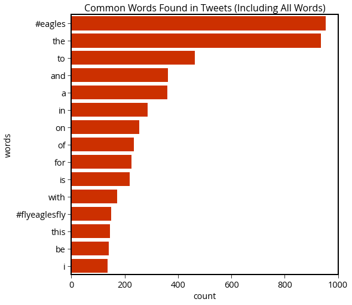

```python
fig, ax = plt.subplots(figsize=(8, 8))

# Plot horizontal bar graph
sns.barplot(
    y="words",
    x="count",
    data=counts_no_urls.sort_values(by="count", ascending=False),
    ax=ax,
    color="#cc3000",
    saturation=1.0,
)

ax.set_title("Common Words Found in Tweets (Including All Words)", fontsize=16)
```

## Step 2: remove stop words and punctuation

Common words that do not carry much significance and are often ignored in text analysis.

We can use the `nltk` package.

The "Natural Language Toolkit" https://www.nltk.org/

## Import and download the stop words

```python
import nltk
nltk.download('stopwords');
```

## Get the list of common stop words

```python
stop_words = list(set(nltk.corpus.stopwords.words('english')))

stop_words[:10]
```

```
["needn't", 'y', 'hasn', 'no', 'isn', 'why', "don't", 'ain', "won't", 'if']
```

```python
len(stop_words)
```

```
179
```

## Get the list of common punctuation

```python
import string
```

```python
punctuation = list(string.punctuation)
```

```python
punctuation[:5]
```

```
['!', '"', '#', '$', '%']
```

## Remove stop words from our tweets

```python
ignored = stop_words + punctuation
```

```python
ignored[:10]
```

```
["needn't", 'y', 'hasn', 'no', 'isn', 'why', "don't", 'ain', "won't", 'if']
```

```python
# Remove stop words from each tweet list of words
tweets_nsw = [[word for word in tweet_words if word not in ignored]
              for tweet_words in words_in_tweet]

tweets_nsw[0]
```

```
['**ending',
 'soon**',
 '#eagles',
 '7"',
 '#vinyl',
 '#single',
 '#1970s',
 'ex/ex',
 'via',
 '@ebay_uk',
 '#records',
 '#oneofthesenights',
 '#ebay']
```

## Get our DataFrame of frequencies

```python
counts_nsw = count_word_frequencies(tweets_nsw)
counts_nsw.head()
```

|  | words | count |
| --- | --- | --- |
| 0 | #eagles | 953 |
| 1 | #flyeaglesfly | 150 |
| 2 | #nfl | 107 |
| 3 | eagles | 96 |
| 4 | get | 79 |

And plot...

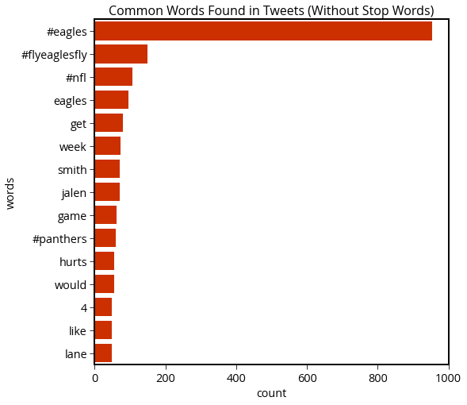

```python
fig, ax = plt.subplots(figsize=(8, 8))

sns.barplot(
    y="words",
    x="count",
    data=counts_nsw.sort_values(by="count", ascending=False),
    ax=ax,
    color="#cc3000",
    saturation=1.0,
)

ax.set_title("Common Words Found in Tweets (Without Stop Words)", fontsize=16);
```

## Step 3: remove our query terms

Now, we'll be left with only the **meanigful** words...

```python
search_terms = ['#eagles', "eagles", "@eagles"]
tweets_final = [[w for w in word if w not in search_terms]
                 for word in tweets_nsw]
```

```python
# frequency counts
counts_final = count_word_frequencies(tweets_final)
```

## And now, plot the cleaned tweets...

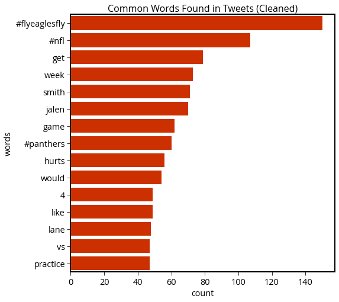

```python
fig, ax = plt.subplots(figsize=(8, 8))

sns.barplot(
    y="words",
    x="count",
    data=counts_final.sort_values(by="count", ascending=False),
    ax=ax,
    color="#cc3000",
    saturation=1.0,
)

ax.set_title("Common Words Found in Tweets (Cleaned)", fontsize=16)
```

## At home exercise

Get 1,000 tweets using a query string of your choice and plot the word frequencies.

Be sure to:

- remove URLs
- remove stop words / punctuation
- remove your search query terms

**Note**: if you try to pull more than 1,000 tweets you will likely run into the rate limit and have to wait 15 minutes.

**Remember:** the [API documentation](https://developer.twitter.com/en/docs/tweets/rules-and-filtering/overview/standard-operators) describes how to customize a query string.

## Use case #2: sentiment analysis

The goal of a **sentiment analysis** is to determine the attitude or emotional state of the person who sent a particular tweet.

Often used by brands to evaluate public opinion about a product.

## The goal:

Determine the "sentiment" of every word in the English language

## The hard way

Train a machine learning algorithm to classify words as positive vs. negative, given an input training sample of words.

## The easy way

Luckily, this is a **very common** task in NLP and there are several packages available that have done the hard work for you.

They provide out-of-the-box sentiment analysis using pre-trained machine learning algorithms.

## We'll be using `textblob`

```python
import textblob
```

## Let's analyze our set of 1,000 #eagles tweets

## Create our "text blobs"

Simply pass the tweet text to the `TextBlob()` object.

**Note:** it's best to remove any URLs first!

```python
blobs = [textblob.TextBlob(remove_url(t.full_text)) for t in tweets]
```

```python
blobs[0]
```

```
TextBlob("**Ending Soon** #EAGLES 7" #VINYL #SINGLE #1970s EX/EX via @eBay_UK #records #OneOfTheseNights #ebay")
```

```python
blobs[0].sentiment
```

```
Sentiment(polarity=-0.07142857142857142, subjectivity=0.21428571428571427)
```

## Combine the data into a DataFrame

Track the polarity, subjectivity, and date of each tweet.

```python
data = {}
data['date'] = [tweet.created_at for tweet in tweets]
data['polarity'] = [blob.sentiment.polarity for blob in blobs]
data['subjectivity'] = [blob.sentiment.subjectivity for blob in blobs]
data['text'] = [remove_url(tweet.full_text) for tweet in tweets]
data = pd.DataFrame(data)
```

```python
data.head()
```

|  | date | polarity | subjectivity | text |
| --- | --- | --- | --- | --- |
| 0 | 2021-10-08 00:57:10 | -0.071429 | 0.214286 | **Ending Soon** #EAGLES 7" #VINYL #SINGLE #197... |
| 1 | 2021-10-08 00:48:11 | -0.400000 | 0.400000 | November 20, 1960 - Chuck Bednarik (60) of the... |
| 2 | 2021-10-08 00:47:09 | 0.000000 | 0.000000 | Every time I watch the #Seahawks I say THANK G... |
| 3 | 2021-10-08 00:40:30 | 0.606534 | 0.602273 | New Kultural Sport Episode!! NFL 2021 WEEK 4 R... |
| 4 | 2021-10-08 00:40:27 | 0.409091 | 0.313636 | NEW: #Eagles Thurs notebook: -OL speculation. ... |

## How many are unbiased?

We can remove tweets with a polarity of zero to get a better sense of emotions.

```python
zero = (data['polarity']==0).sum()
print("number of unbiased tweets = ", zero)
```

```
number of unbiased tweets =  366
```

```python
# remove unbiased tweets
biased = data.loc[ data['polarity'] != 0 ].copy()
```

## What does a polarized tweet look like?

We can find the tweet with the maximum positive/negative scores

### The most negative

Use the `idxmin()` function:

```python
biased.loc[biased['polarity'].idxmin(), 'text']
```

```
'This was nasty.. @DeVontaSmith_6 #Eagles'
```

### The most positive

Use the `idxmax()` function

```python
biased.loc[biased['polarity'].idxmax(), 'text']
```

```
'Eagles are underdogs to one of the NFL’s best teams against the spread #NFLBeast #NFL #NFLTwitter #NFLUpdate #NFLNews #NFLBlogs #Philadelphia #Eagles #PhiladelphiaEagles #NFC #BleedingGreenNation By: Brandon Lee Gowton Mark J. Rebilas-USA TODAY ...'
```

## Plot a histogram of polarity

**Important:** Polarity runs from -1 (most negative) to +1 (most positive)

We can use matplotlib's `hist()` function:

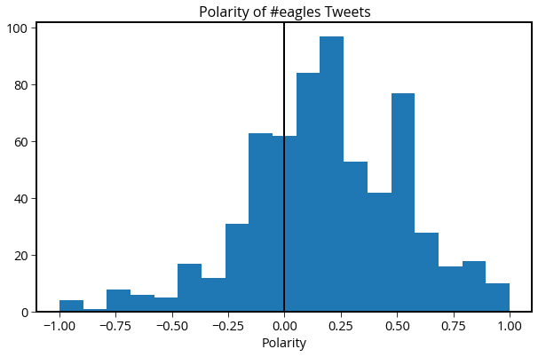

```python
# create a figure and axes
fig, ax = plt.subplots(figsize=(10, 6))

# histogram
ax.hist(biased['polarity'], bins='auto')
ax.axvline(x=0, c='k', lw=2)

# format
ax.set_xlabel("Polarity")
ax.set_title("Polarity of #eagles Tweets", fontsize=16);
```

```python
biased['polarity'].median()
```

```
0.1777087279040404
```

```python
biased['polarity'].mean()
```

```
0.1813234361242552
```

## And subjectivity too...

### The most objective

```python
biased.loc[biased['subjectivity'].idxmin(), 'text']
```

```
'It was “dress like your team day” on our “Jean-tober” calendar! Thankful for this leadership team and their passion for our @brookglenn3 students (Missing Marie🤣)! @theotooles @BerniceMJackso1 @MarieHavran #soaringtonewheights #Eagles'
```

### The most subjective

```python
biased.loc[biased['subjectivity'].idxmax(), 'text']
```

```
'Got to cheer on both of my favorite schools at the volleyball match! #eagles #dragons #wearefcs 🏐'
```

## The distribution of subjectivity

**Important:** Subjectivity runs from 0 (most objective) to +1 (most subjective)

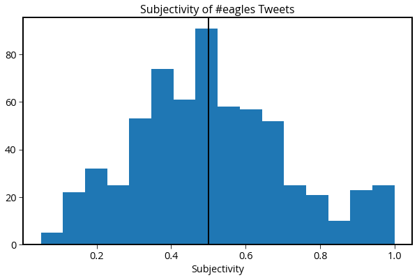

```python
# create a figure and axes
fig, ax = plt.subplots(figsize=(10, 6))

# histogram
ax.hist(biased['subjectivity'], bins='auto')
ax.axvline(x=0.5, c='k', lw=2)

# format
ax.set_xlabel("Subjectivity")
ax.set_title("Subjectivity of #eagles Tweets", fontsize=16);
```

## How does polarity influence subjectivity?

Are positive/negative tweets more or less objective?

## Seaborn's `regplot()` function

Is there a linear trend?

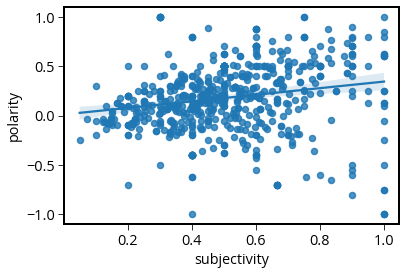

```python
ax = sns.regplot(x=biased['subjectivity'], y=biased['polarity'])
```

## Seaborn's `kdeplot()`

Shade the bivariate relationship

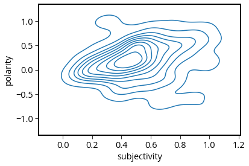

```python
ax = sns.kdeplot(data=biased['subjectivity'], data2=biased['polarity'])
```

**Insight**: the most subjective tweets tend to be most polarized as well...

## Let's check for hourly trends too

We can plot the distribution of polarity by the tweet's hour

First, we'll add a new column that gives the day and hour of the tweet.

We can use the built-in [strftime()](http://strftime.org/) function.

```python
# this is month/day hour AM/PM
biased['date_string'] = biased['date'].dt.strftime("%-m/%d %I %p")
```

```python
biased.head()
```

|  | date | polarity | subjectivity | text | date_string |
| --- | --- | --- | --- | --- | --- |
| 0 | 2021-10-08 00:57:10 | -0.071429 | 0.214286 | **Ending Soon** #EAGLES 7" #VINYL #SINGLE #197... | 10/08 12 AM |
| 1 | 2021-10-08 00:48:11 | -0.400000 | 0.400000 | November 20, 1960 - Chuck Bednarik (60) of the... | 10/08 12 AM |
| 3 | 2021-10-08 00:40:30 | 0.606534 | 0.602273 | New Kultural Sport Episode!! NFL 2021 WEEK 4 R... | 10/08 12 AM |
| 4 | 2021-10-08 00:40:27 | 0.409091 | 0.313636 | NEW: #Eagles Thurs notebook: -OL speculation. ... | 10/08 12 AM |
| 5 | 2021-10-08 00:39:01 | 0.291667 | 0.416667 | Excited to watch former #Eagles CB, Sidney Jon... | 10/08 12 AM |

Sort the tweets in chronological order...

```python
biased = biased.sort_values(by='date', ascending=True)
```

## Make a box and whiskers plot of the polarity

Use Seaborn's `boxplot()` function

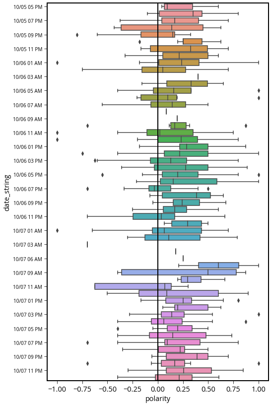

```python
fig, ax = plt.subplots(figsize=(8, 14))

sns.boxplot(y='date_string', x='polarity', data=biased, ax=ax)
ax.axvline(x=0, c='k', lw=2) # neutral

# Set yticks to every other hour
yticks = ax.get_yticks()
ax.set_yticks(range(0, len(yticks), 2))
plt.setp(ax.get_yticklabels(), fontsize=10);
```

## And subjectivity over time...

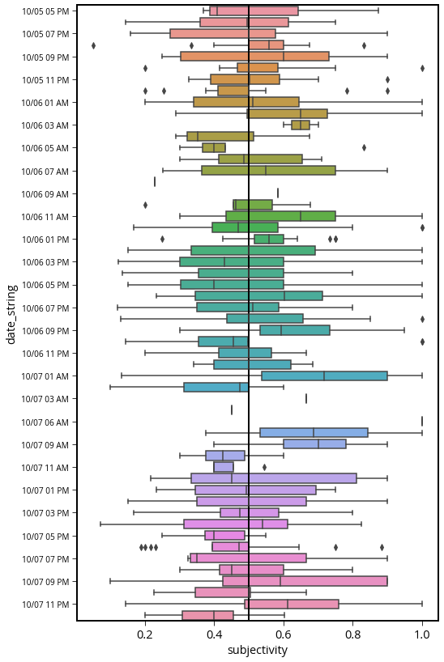

```python
fig, ax = plt.subplots(figsize=(8,14))

sns.boxplot(y='date_string', x='subjectivity', data=biased)
ax.axvline(x=0.5, c='k', lw=2) # neutral

# Set yticks to every other hour
yticks = ax.get_yticks()
ax.set_yticks(range(0, len(yticks), 2))
plt.setp(ax.get_yticklabels(), fontsize=10);
```

## At home exercise: sentiment analysis

Analyze your set of tweets from the last exercise (or get a new set), and explore the sentiments by:

- plotting histograms of the subjectivity and polarity
- finding the most/least subjective and polarized tweets
- plotting the relationship between polarity and subjectivity
- showing hourly trends in polarity/subjectivity

Or explore trends in some new way!

## That's it!

- Next week: creating your own datasets through web scraping
- See you on Monday!